# ANÁLISIS EXPLORATORIO POR PAISES.CONTRASTE DE MUESTRAS

Alicia Perdices Guerra

22 de mayo, 2021

- **1.ANÁLISIS EXPLORATORIO POR PAISES.DIÁLISIS Y TRASPLANTE**
  - 1.1 ANÁLISIS DE DATOS
    - 1.1.1 Se filtra informacion (De todas los archivos disponibles)
    - 1.1.2 Se genera variable con la información necesaria en relación con Ratio de Trasplantados y Pacientes en Diálisis.
  - 1.2 CONTRASTE DE MUESTRAS, PARA 2005 Y 2014. EVOLUCIÓN
- **2.ANÁLISIS EXPLORATORIO POR PAISES.MORTALIDAD PREVENIBLE Y TRATABLE**
  - 2.1 ANÁLISIS DE DATOS
    - 2.1.1 Se filtra informacion (De todas los archivos disponibles)
    - 2.1.2 Se genera variable con la información necesaria en relación con la mortalidad prevenible y tratable.
  - 2.2 CONTRASTE DE MUESTRAS, PARA 2011 Y 2017. EVOLUCIÓN

#### **1.ANÁLISIS DE DATOS. DIÁLISIS Y TRASPLANTE**

**1.1 ANÁLISIS DE DATOS**

Se procede en primer lugar a cargar todos los archivos para poder realizar el análisis.

```r
ratio_Pacientes_Dialisis<-read.csv("C:/temp/Ratio_Pacientes_Dialisis_Analisis.csv",sep= ",")
ratio_Pacientes_Trasplantados<-read.csv("C:/temp/Ratio_Pacientes_Trasplantados_Analisis.csv",sep= ",")
summary(ratio_Pacientes_Dialisis)
```

```
##       TIME            GEO                                    UNIT
##  Min.   :2005   Austria : 10   Per hundred thousand inhabitants:290
##  1st Qu.:2007   Belgium : 10
##  Median :2010   Bulgaria: 10
##  Mean   :2010   Croatia : 10
##  3rd Qu.:2012   Czechia : 10
##  Max.   :2014   Denmark : 10
##                 (Other) :230
##            ICD9CM        Value        Value_imp
##  Haemodialysis:290   Min.   :  0.00   Mode :logical
##                      1st Qu.: 45.92   FALSE:187
##                      Median : 59.09   TRUE :103
##                      Mean   : 56.62
##                      3rd Qu.: 67.17
##                      Max.   :113.25
##
```

```r
summary(ratio_Pacientes_Trasplantados)
```

```
##       TIME            GEO                                    UNIT
##  Min.   :2005   Austria : 10   Per hundred thousand inhabitants:290
##  1st Qu.:2007   Belgium : 10
##  Median :2010   Bulgaria: 10
##  Mean   :2010   Croatia : 10
##  3rd Qu.:2012   Czechia : 10
##  Max.   :2014   Denmark : 10
##                 (Other) :230
##                        ICD9CM        Value       Value_imp
##  Transplantation of kidney:290   Min.   : 0.00   Mode :logical
##                                  1st Qu.:26.51   FALSE:152
##                                  Median :34.75   TRUE :138
##                                  Mean   :33.16
##                                  3rd Qu.:41.82
##                                  Max.   :65.00
##
```

**1.1.1 Se filtra informacion (De todas los archivos disponibles)**

```r
nrow(ratio_Pacientes_Dialisis)
```

```
## [1] 290
```

```r
nrow(ratio_Pacientes_Trasplantados)
```

```
## [1] 290
```

```r
head(ratio_Pacientes_Trasplantados)
```

```
##   TIME                                              GEO
## 1 2005                                          Belgium
## 2 2005                                         Bulgaria
## 3 2005                                          Czechia
## 4 2005                                          Denmark
## 5 2005 Germany (until 1990 former territory of the FRG)
## 6 2005                                          Estonia
##                               UNIT                    ICD9CM Value Value_imp
## 1 Per hundred thousand inhabitants Transplantation of kidney 39.88     FALSE
## 2 Per hundred thousand inhabitants Transplantation of kidney 31.02      TRUE
## 3 Per hundred thousand inhabitants Transplantation of kidney 35.37      TRUE
## 4 Per hundred thousand inhabitants Transplantation of kidney 31.02     FALSE
## 5 Per hundred thousand inhabitants Transplantation of kidney 28.77     FALSE
## 6 Per hundred thousand inhabitants Transplantation of kidney 29.47      TRUE
```

```r
head(ratio_Pacientes_Dialisis)
```

```
##   TIME                                              GEO
## 1 2005                                          Belgium
## 2 2005                                         Bulgaria
## 3 2005                                          Czechia
## 4 2005                                          Denmark
## 5 2005 Germany (until 1990 former territory of the FRG)
## 6 2005                                          Estonia
##                               UNIT        ICD9CM Value Value_imp
## 1 Per hundred thousand inhabitants Haemodialysis 59.09     FALSE
## 2 Per hundred thousand inhabitants Haemodialysis 59.09      TRUE
## 3 Per hundred thousand inhabitants Haemodialysis 56.01     FALSE
## 4 Per hundred thousand inhabitants Haemodialysis 46.57     FALSE
## 5 Per hundred thousand inhabitants Haemodialysis 76.91     FALSE
## 6 Per hundred thousand inhabitants Haemodialysis 56.01      TRUE
```

**1.1.2 Se genera variable con la información necesaria en relación con Ratio de Trasplantados y Pacientes en Diálisis**

**DIÁLISIS**

- Se crea un DataFrame con toda la información:

```r
year<-ratio_Pacientes_Trasplantados$TIME
country<-ratio_Pacientes_Trasplantados$GEO
renal<-data.frame(TIME=year,GEO=country,
                  P_Dialisis=ratio_Pacientes_Dialisis$Value,
                  P_Trasplantados=ratio_Pacientes_Trasplantados$Value)
head(renal)
```

```
##   TIME                                              GEO P_Dialisis
## 1 2005                                          Belgium      59.09
## 2 2005                                         Bulgaria      59.09
## 3 2005                                          Czechia      56.01
## 4 2005                                          Denmark      46.57
## 5 2005 Germany (until 1990 former territory of the FRG)      76.91
## 6 2005                                          Estonia      56.01
##   P_Trasplantados
## 1           39.88
## 2           31.02
## 3           35.37
## 4           31.02
## 5           28.77
## 6           29.47
```

- Se crean dos muestras pareadas, Dialisis en el año 2005 y en el 2014 (10 años después)

```r
renal_2005<-filter(renal,renal$TIME==2005)
dialisis_2005<-renal[renal_2005$P_Dialisis,]



renal_2014<-filter(renal,renal$TIME==2014)
dialisis_2014<-renal[renal_2014$P_Dialisis,]
```

**TRASPLANTADOS**

- Se crean dos muestras pareadas, Trasplantados en el año 2005 y en el 2014 (10 años después)

```r
renal_2005<-filter(renal,renal$TIME==2005)
trasplante_2005<-renal[renal_2005$P_Trasplantados,]


renal_2014<-filter(renal,renal$TIME==2014)
trasplante_2014<-renal[renal_2014$P_Trasplantados,]
```

**1.2 CONTRASTE DE MUESTRAS, PARA 2005 Y 2014. EVOLUCIÓN**

- **¿Se puede afirmar que aumentarán el ratio de Pacientes en Diálisis con los años?**

Como es una muestra pareada, se calculará la diferencia de muestras y por tanto las hipótesis son:

H0: $\mu_{dif}$=0

H1: $\mu_{dif}$>0

- Asunción de Normalidad
  - No se puede aplicar el Teorema del límite Central ya que la muestra no supera los 30 registros.
  - Se interpretan las gráficas Q_Q y se aplica el test_de_Shapiro.

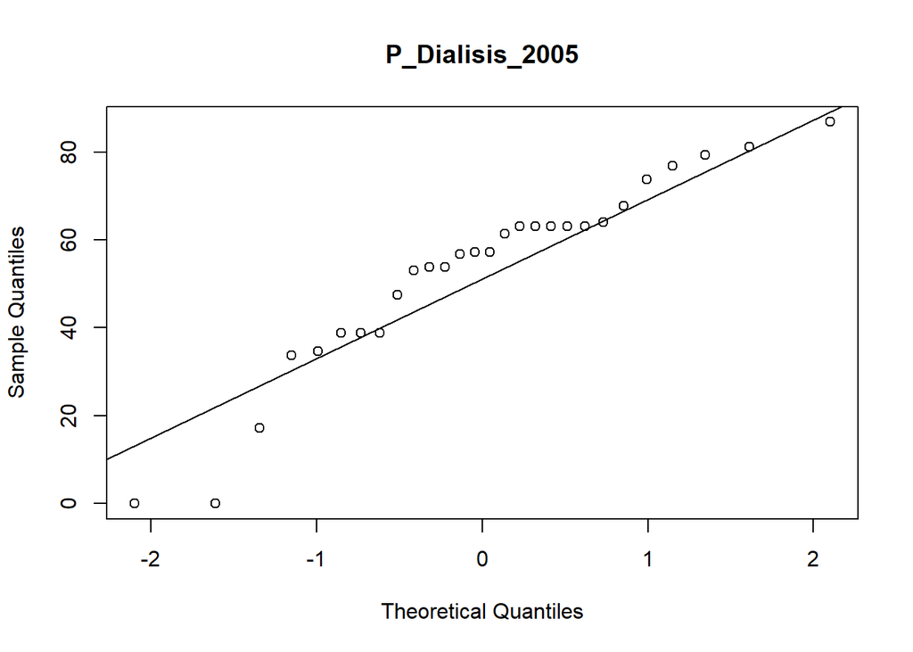

```r
qqnorm(dialisis_2005$P_Dialisis, main="P_Dialisis_2005")
qqline(dialisis_2005$P_Dialisis)
```

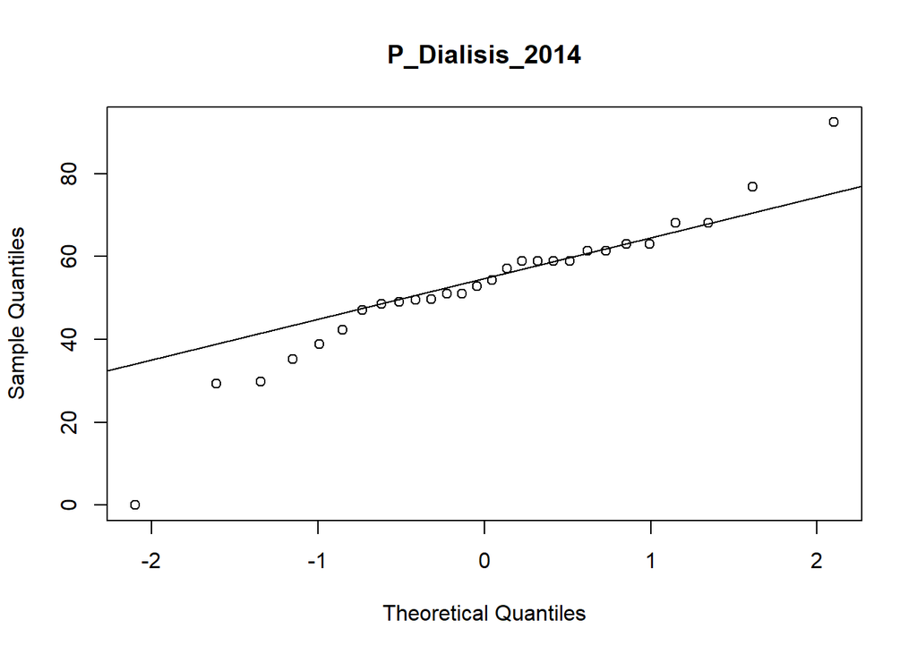

```r
qqnorm(dialisis_2014$P_Dialisis, main="P_Dialisis_2014")
qqline(dialisis_2014$P_Dialisis)
```

```r
shapiro.test(dialisis_2005$P_Dialisis)
```

```
##
##  Shapiro-Wilk normality test
##
## data:  dialisis_2005$P_Dialisis
## W = 0.91427, p-value = 0.0251
```

```r
shapiro.test(dialisis_2014$P_Dialisis)
```

```
##
##  Shapiro-Wilk normality test
##
## data:  dialisis_2014$P_Dialisis
## W = 0.93021, p-value = 0.06241
```

Interpretación:

- Los gráficos Q-Q muestan una desviación respecto de la normal pronunciada en los extremos sobre todo para la muestra de 2014 y en general para la de 2005.
- Con un valor de confianza del 95% podemos rechazar la hipótesis nula de normalidad en la muestra de Diálisis del año 2005( p-value = 0.0251).

-Dados estos resultados se aplica un test no paramétrico: Existen dos test no paramétricos para el contraste de muestras:

- Test de suma de rangos(Mann-Whitney)
- Test de rangos y signos de Wilcoxon (Para muestras pareadas)

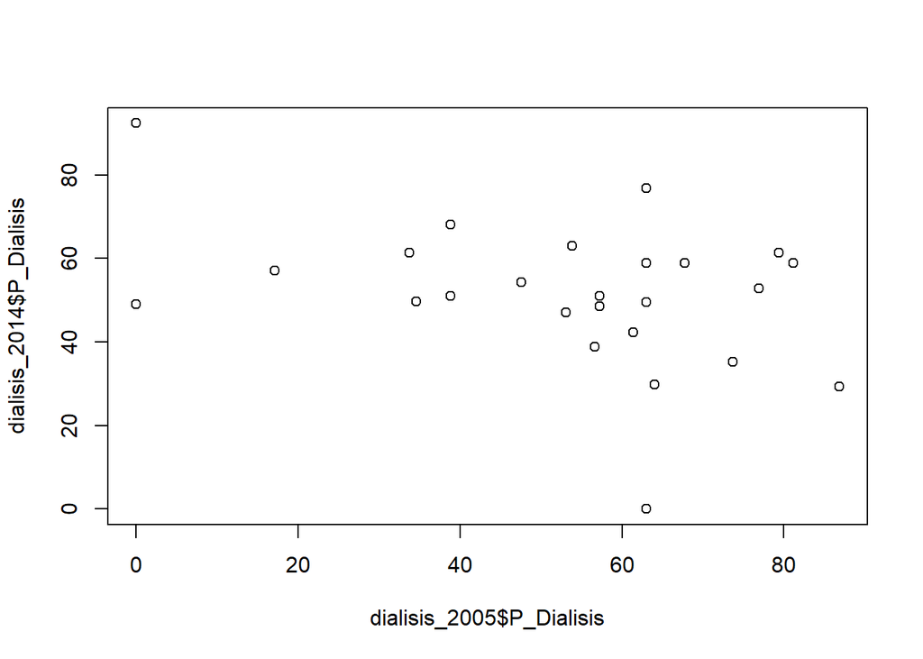

```r
#Se muestra la relación existente entre los pacientes en Diálisis en 2005 y 10 años después.
plot(dialisis_2005$P_Dialisis,dialisis_2014$P_Dialisis)
```

```r
#Se realiza el contraste.
wilcox.test(dialisis_2005$P_Dialisis,
            dialisis_2014$P_Dialisis, paired=TRUE, alternative="greater")
```

```
##
##  Wilcoxon signed rank test with continuity correction
##
## data:  dialisis_2005$P_Dialisis and dialisis_2014$P_Dialisis
## V = 212, p-value = 0.4233
## alternative hypothesis: true location shift is greater than 0
```

Interpretación:

No podemos rechazar la hipótesis nula (pvalue=0.4233>0.05). Por tanto no podemos afirmar que el ratio de pacientes en Diálisis haya aumentado en un periodo de 10 años.

- **¿Se puede afirmar que aumentarán el ratio de Pacientes Trasplantados con los años?**

Como es una muestra pareada, se calculará la diferencia de muestras y por tanto las hipótesis son:

H0: $\mu_{dif}$=0

H1: $\mu_{dif}$>0

- Asunción de Normalidad
  - No se puede aplicar el Teorema del límite Central ya que la muestra no supera los 30 registros.
  - Se interpretan las gráficas Q_Q y se aplica el test_de_Shapiro.

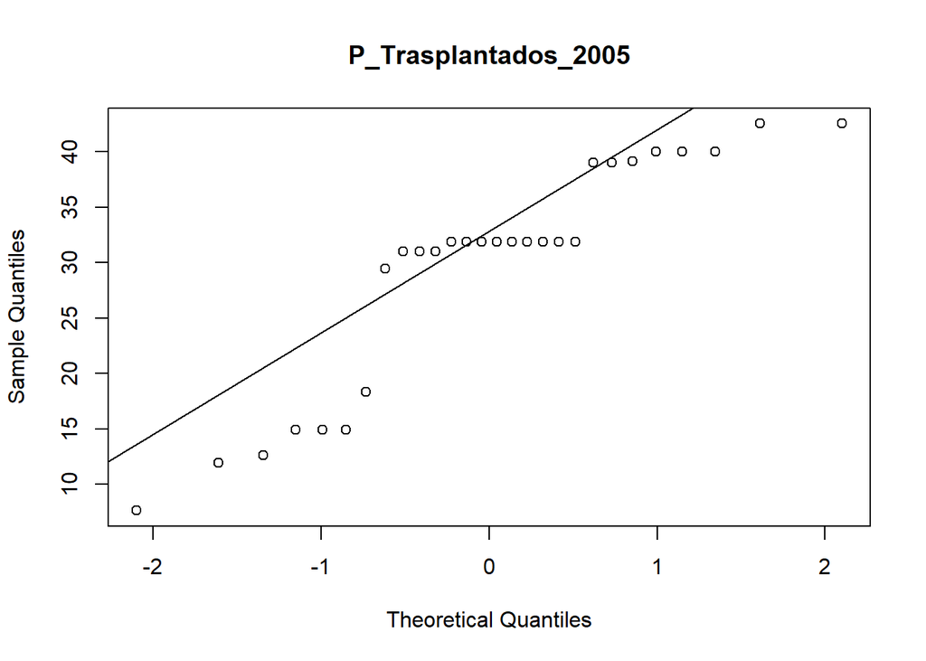

```r
qqnorm(trasplante_2005$P_Trasplantados, main="P_Trasplantados_2005")
qqline(trasplante_2005$P_Trasplantados)
```

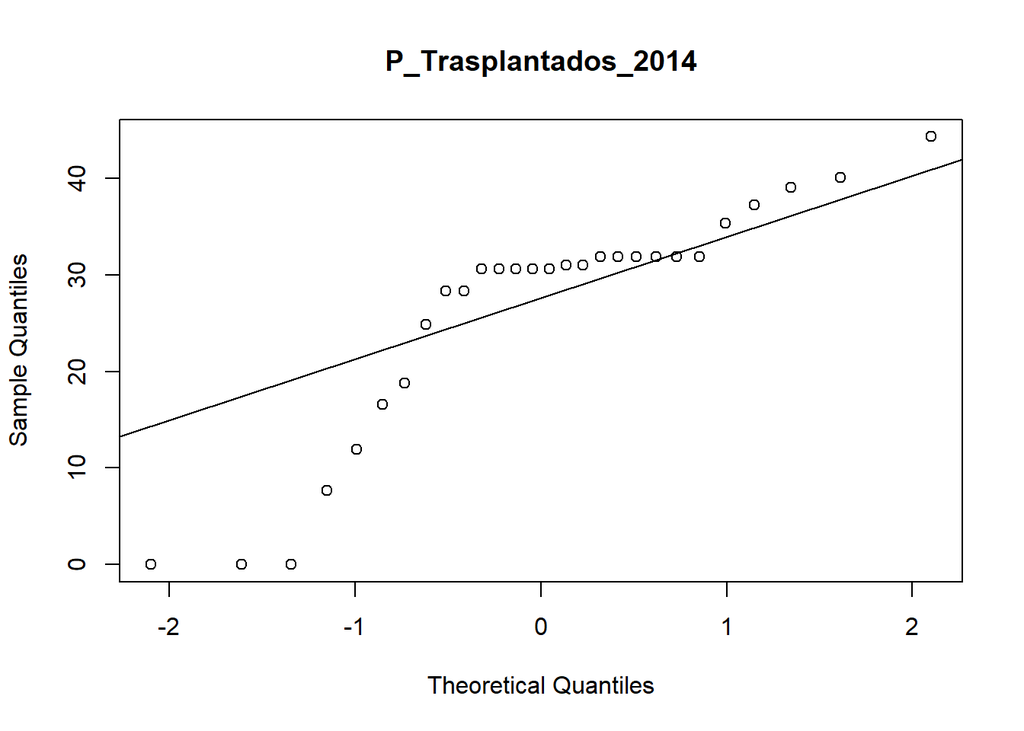

```r
qqnorm(trasplante_2014$P_Trasplantados, main="P_Trasplantados_2014")
qqline(trasplante_2014$P_Trasplantados)
```

```r
shapiro.test(dialisis_2005$P_Trasplantados)
```

```
##
##  Shapiro-Wilk normality test
##
## data:  dialisis_2005$P_Trasplantados
## W = 0.89433, p-value = 0.008448
```

```r
shapiro.test(dialisis_2014$P_Trasplantados)
```

```
##
##  Shapiro-Wilk normality test
##
## data:  dialisis_2014$P_Trasplantados
## W = 0.89857, p-value = 0.0106
```

Interpretación:

- Los gráficos Q-Q muestan una desviación respecto de la normal pronunciada tanto para 2005 como para 2014.
- Con un valor de confianza del 95% podemos rechazar la hipótesis nula de normalidad en las dos muestras( p-value < 0.05 en ambos casos).

-Dados estos resultados se aplica un test no paramétrico: Como es una muestra pareada se aplica el test de rangos y signos de Wilcoxon :

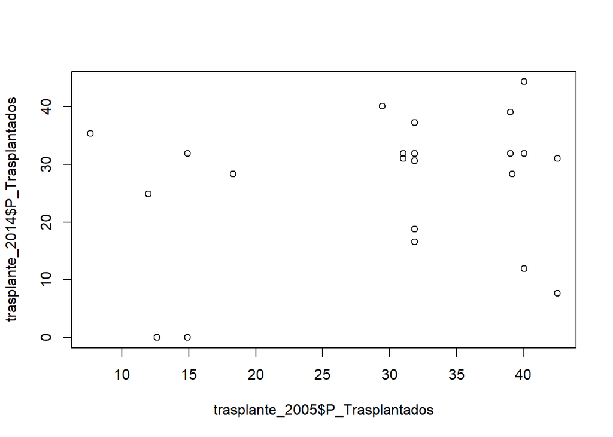

```r
#Se muestra la relación existente entre los pacientes Trasplantados en 2005 y 10 años después.
plot(trasplante_2005$P_Trasplantados,trasplante_2014$P_Trasplantados)
```

```r
#Se realiza el contraste.
wilcox.test(trasplante_2005$P_Trasplantados,
            trasplante_2014$P_Trasplantados, paired=TRUE, alternative="greater")
```

```
##
##  Wilcoxon signed rank test with continuity correction
##
## data:  trasplante_2005$P_Trasplantados and trasplante_2014$P_Trasplantados
## V = 218, p-value = 0.06926
## alternative hypothesis: true location shift is greater than 0
```

Interpretación:

- No podemos rechazar la hipótesis nula (pvalue=0.069>0.05). Por tanto no podemos afirmar que el ratio de pacientes Trasplantados haya aumentado en un periodo de 10 años.

#### **2.ANÁLISIS DE DATOS. MORTALIDAD TRATABLE Y PREVENIBLE**

**2.1 ANÁLISIS DE DATOS**

Se procede en primer lugar a cargar todos los archivos para poder realizar el análisis.

```r
mortalidad<-read.csv("C:/temp/Mortalidad_Analisis.csv",sep= ",")
summary(mortalidad)
```

```
##       TIME            Pais     Mortalidad_Prevenible Mortalidad_Tratable
##  Min.   :2011   Austria :  7   Min.   :    31        Min.   :   16
##  1st Qu.:2012   Belgium :  7   1st Qu.:  5566        1st Qu.: 2890
##  Median :2014   Bulgaria:  7   Median : 12088        Median : 6690
##  Mean   :2014   Croatia :  7   Mean   : 25246        Mean   :14927
##  3rd Qu.:2016   Cyprus  :  7   3rd Qu.: 30438        3rd Qu.:16565
##  Max.   :2017   Czechia :  7   Max.   :127461        Max.   :74029
##                 (Other) :196
##  Mortalidad_A00_B99 Mortalidad_G00_R50 Mortalidad_pneumonia  Other_sepsis
##  Min.   :   1.00    Min.   :    1.0    Min.   :    1.0      Min.   :   1.00
##  1st Qu.:  76.75    1st Qu.:  653.8    1st Qu.:  347.5      1st Qu.:  76.75
##  Median : 288.00    Median : 1488.5    Median : 1150.0      Median : 288.00
##  Mean   :1335.32    Mean   : 3958.5    Mean   : 3890.2      Mean   :1335.32
##  3rd Qu.:1435.75    3rd Qu.: 4149.2    3rd Qu.: 5160.2      3rd Qu.:1435.75
##  Max.   :9656.00    Max.   :22501.0    Max.   :31593.0      Max.   :9656.00
##
```

**2.1.1 Se filtra informacion (De todas los archivos disponibles)**

```r
nrow(mortalidad)
```

```
## [1] 238
```

```r
head(mortalidad)
```

```
##   TIME                                             Pais Mortalidad_Prevenible
## 1 2011                                          Belgium               15883.5
## 2 2011                                         Bulgaria               15459.5
## 3 2011                                          Czechia               20972.5
## 4 2011                                          Denmark                9022.0
## 5 2011 Germany (until 1990 former territory of the FRG)              127461.0
## 6 2011                                          Estonia                3555.0
##   Mortalidad_Tratable Mortalidad_A00_B99 Mortalidad_G00_R50
## 1              7459.5               1148               2994
## 2             13422.5                233               1227
## 3             13383.5                714               2336
## 4              4445.0                250               1954
## 5             74029.0               7411              15593
## 6              1870.0                  3                347
##   Mortalidad_pneumonia Other_sepsis
## 1                 3260         1148
## 2                 1200          233
## 3                 2073          714
## 4                  890          250
## 5                18020         7411
## 6                   29            3
```

**2.1.2 Se genera variable con la información necesaria en relación con la Mortalidad Tratable y Prevenible**

**MORTALIDAD PREVENIBLE**

- Se crean dos muestras pareadas, Mortalidad Prevenible en el año 2011 y en el 2017 (6 años después)

```r
mortalidad_2011<-filter(mortalidad,mortalidad$TIME==2011)
mortalidad_2011<-select(mortalidad_2011,TIME,Pais,Mortalidad_Prevenible)
head(mortalidad_2011)
```

```
##   TIME                                             Pais Mortalidad_Prevenible
## 1 2011                                          Belgium               15883.5
## 2 2011                                         Bulgaria               15459.5
## 3 2011                                          Czechia               20972.5
## 4 2011                                          Denmark                9022.0
## 5 2011 Germany (until 1990 former territory of the FRG)              127461.0
## 6 2011                                          Estonia                3555.0
```

```r
nrow(mortalidad_2011)
```

```
## [1] 34
```

```r
mortalidad_2017<-filter(mortalidad,mortalidad$TIME==2017)
mortalidad_2017<-select(mortalidad_2017,TIME,Pais,Mortalidad_Prevenible)
head(mortalidad_2017)
```

```
##   TIME                                             Pais Mortalidad_Prevenible
## 1 2017                                          Belgium               14923.0
## 2 2017                                         Bulgaria               16374.5
## 3 2017                                          Czechia               20169.5
## 4 2017                                          Denmark                8494.0
## 5 2017 Germany (until 1990 former territory of the FRG)              118506.5
## 6 2017                                          Estonia                2889.0
```

```r
nrow(mortalidad_2017)
```

```
## [1] 34
```

**MORTALIDAD TRATABLE**

- Se crean dos muestras pareadas, Mortalidad Tratable en el año 2011 y en el 2017 (6 años después)

```r
mortalidad_2011t<-filter(mortalidad,mortalidad$TIME==2011)
head(mortalidad_2011t)
```

```
##   TIME                                             Pais Mortalidad_Prevenible
## 1 2011                                          Belgium               15883.5
## 2 2011                                         Bulgaria               15459.5
## 3 2011                                          Czechia               20972.5
## 4 2011                                          Denmark                9022.0
## 5 2011 Germany (until 1990 former territory of the FRG)              127461.0
## 6 2011                                          Estonia                3555.0
##   Mortalidad_Tratable Mortalidad_A00_B99 Mortalidad_G00_R50
## 1              7459.5               1148               2994
## 2             13422.5                233               1227
## 3             13383.5                714               2336
## 4              4445.0                250               1954
## 5             74029.0               7411              15593
## 6              1870.0                  3                347
##   Mortalidad_pneumonia Other_sepsis
## 1                 3260         1148
## 2                 1200          233
## 3                 2073          714
## 4                  890          250
## 5                18020         7411
## 6                   29            3
```

```r
mortalidad_2011t<-select(mortalidad_2011t,TIME,Pais,Mortalidad_Tratable)
head(mortalidad_2011t)
```

```
##   TIME                                             Pais Mortalidad_Tratable
## 1 2011                                          Belgium              7459.5
## 2 2011                                         Bulgaria             13422.5
## 3 2011                                          Czechia             13383.5
## 4 2011                                          Denmark              4445.0
## 5 2011 Germany (until 1990 former territory of the FRG)             74029.0
## 6 2011                                          Estonia              1870.0
```

```r
nrow(mortalidad_2011t)
```

```
## [1] 34
```

```r
mortalidad_2017t<-filter(mortalidad,mortalidad$TIME==2017)
mortalidad_2017t<-select(mortalidad_2017t,TIME,Pais,Mortalidad_Tratable)
head(mortalidad_2017t)
```

```
##   TIME                                             Pais Mortalidad_Tratable
## 1 2017                                          Belgium              7020.0
## 2 2017                                         Bulgaria             13664.5
## 3 2017                                          Czechia             13087.5
## 4 2017                                          Denmark              3990.0
## 5 2017 Germany (until 1990 former territory of the FRG)             64417.5
## 6 2017                                          Estonia              1571.0
```

```r
nrow(mortalidad_2017t)
```

```
## [1] 34
```

**2.2 CONTRASTE DE MUESTRAS, PARA 2011 Y 2017. EVOLUCIÓN**

- **¿Se puede afirmar que aumentará la mortalidad prevenible con los años?**

Como es una muestra pareada, se calculará la diferencia de muestras y por tanto las hipótesis son:

H0: $\mu_{dif}$=0

H1: $\mu_{dif}$>0

- Asunción de Normalidad
  - Se podría aplicar el Teorema del límite Central ya que la muestra supera los 30 registros.(34)
  - Pero se interpretan las gráficas Q_Q y se aplica el test_de_Shapiro.

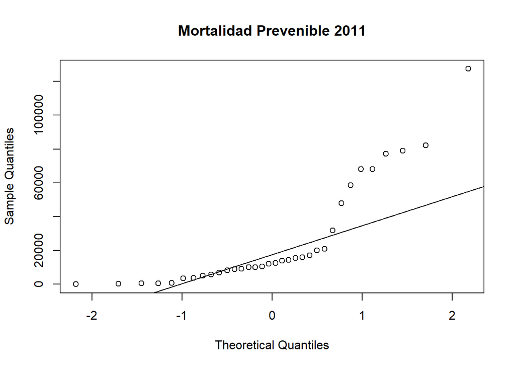

```r
qqnorm(mortalidad_2011$Mortalidad_Prevenible, main="Mortalidad Prevenible 2011")
qqline(mortalidad_2011$Mortalidad_Prevenible)
```

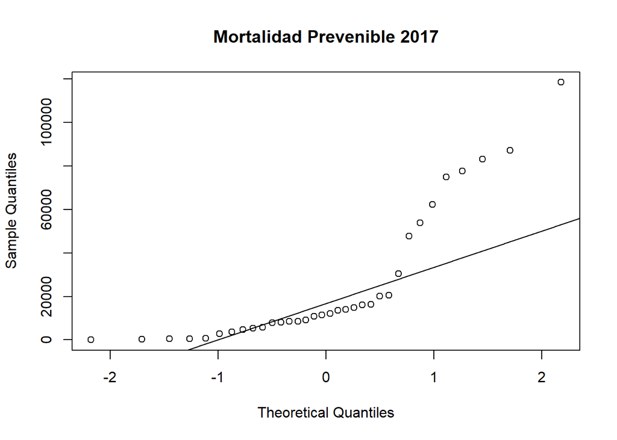

```r
qqnorm(mortalidad_2017$Mortalidad_Prevenible, main="Mortalidad Prevenible 2017")
qqline(mortalidad_2017$Mortalidad_Prevenible)
```

```r
shapiro.test(mortalidad_2011$Mortalidad_Prevenible)
```

```
##
##  Shapiro-Wilk normality test
##
## data:  mortalidad_2011$Mortalidad_Prevenible
## W = 0.75044, p-value = 3.224e-06
```

```r
shapiro.test(mortalidad_2017$Mortalidad_Prevenible)
```

```
##
##  Shapiro-Wilk normality test
##
## data:  mortalidad_2017$Mortalidad_Prevenible
## W = 0.75066, p-value = 3.252e-06
```

Interpretación:

- Los gráficos Q-Q muestan una desviación respecto de la normal pronunciada para ambos años (2011,2017)
- Con un valor de confianza del 95% podemos rechazar la hipótesis nula de normalidad en ambas muestras( p-value < 0.05).

-Dados estos resultados se aplica un test no paramétrico:

Como es una muestra pareada se aplica el test de rangos y signos de Wilcoxon :

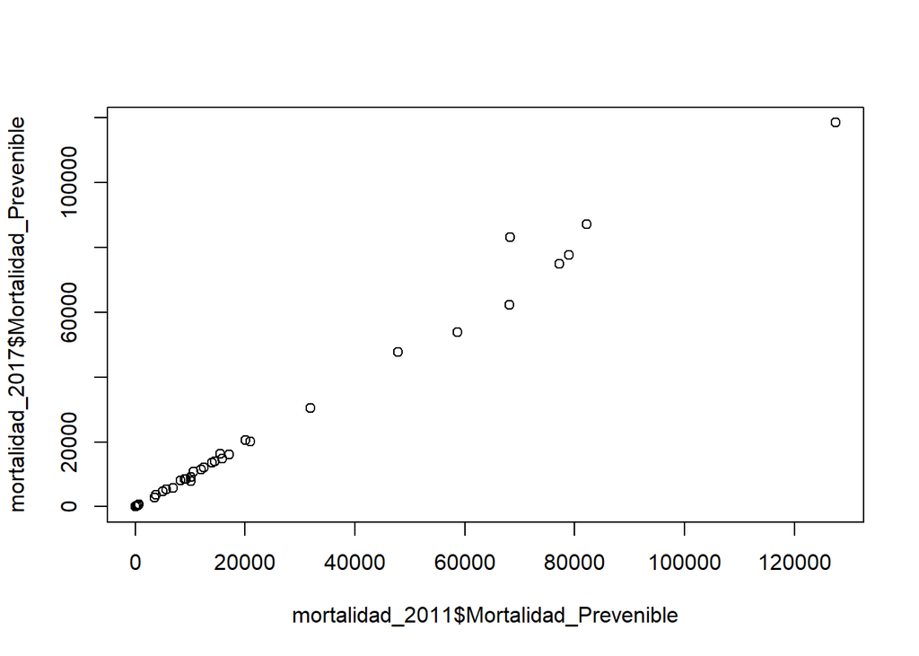

```r
#Se muestra la relación existente entre la Mortalidad Prevenible en 2011 y 6 años después.
plot(mortalidad_2011$Mortalidad_Prevenible,mortalidad_2017$Mortalidad_Prevenible)
```

```r
#Se realiza el contraste.
wilcox.test(mortalidad_2011$Mortalidad_Prevenible,
            mortalidad_2017$Mortalidad_Prevenible, paired=TRUE, alternative="greater")
```

```
##
##  Wilcoxon signed rank test
##
## data:  mortalidad_2011$Mortalidad_Prevenible and mortalidad_2017$Mortalidad_Prevenible
## V = 472, p-value = 0.001092
## alternative hypothesis: true location shift is greater than 0
```

- **¿Se puede afirmar que aumentará la mortalidad tratable con los años?**

Como es una muestra pareada, se calculará la diferencia de muestras y por tanto las hipótesis son:

H0: $\mu_{dif}$=0

H1: $\mu_{dif}$>0

- Asunción de Normalidad
  - Se podría aplicar el Teorema del límite Central ya que la muestra supera los 30 registros.(34)
  - Pero se interpretan las gráficas Q_Q y se aplica el test_de_Shapiro.

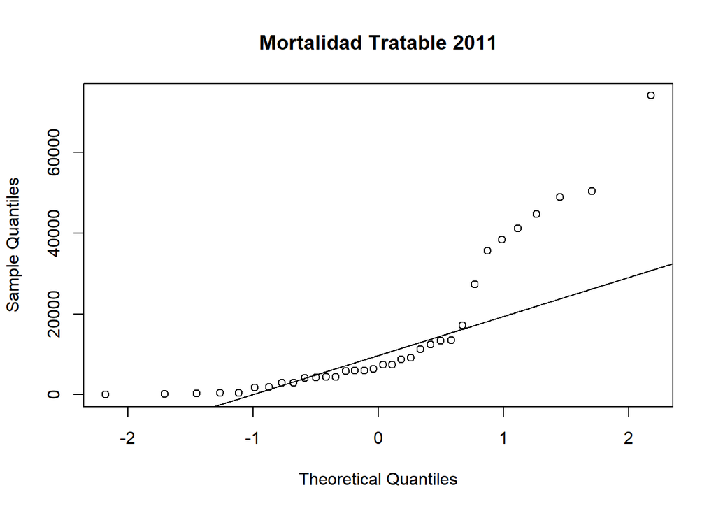

```r
qqnorm(mortalidad_2011t$Mortalidad_Tratable, main="Mortalidad Tratable 2011")
qqline(mortalidad_2011t$Mortalidad_Tratable)
```

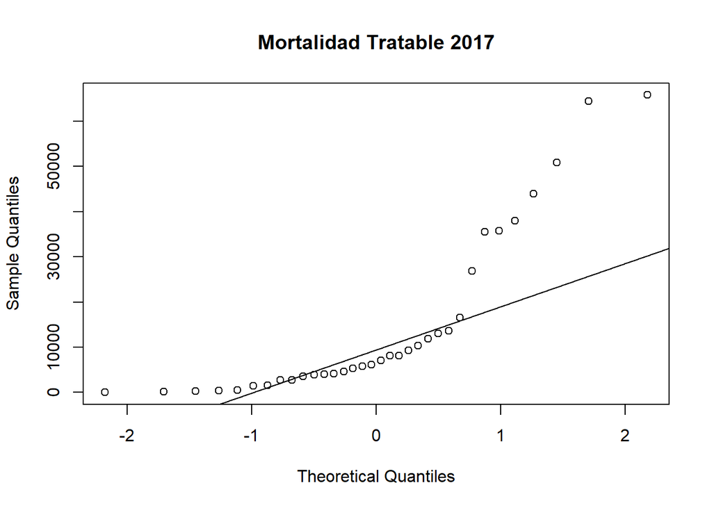

```r
qqnorm(mortalidad_2017t$Mortalidad_Tratable, main="Mortalidad Tratable 2017")
qqline(mortalidad_2017t$Mortalidad_Tratable)
```

```r
shapiro.test(mortalidad_2011t$Mortalidad_Tratable)
```

```
##
##  Shapiro-Wilk normality test
##
## data:  mortalidad_2011t$Mortalidad_Tratable
## W = 0.75944, p-value = 4.613e-06
```

```r
shapiro.test(mortalidad_2017t$Mortalidad_Tratable)
```

```
##
##  Shapiro-Wilk normality test
##
## data:  mortalidad_2017t$Mortalidad_Tratable
## W = 0.74896, p-value = 3.041e-06
```

Interpretación:

- Los gráficos Q-Q muestan una desviación respecto de la normal pronunciada para ambos años (2011,2017)
- Con un valor de confianza del 95% podemos rechazar la hipótesis nula de normalidad en ambas muestras( p-value < 0.05).

-Dados estos resultados se aplica un test no paramétrico:

Como es una muestra pareada se aplica el test de rangos y signos de Wilcoxon :

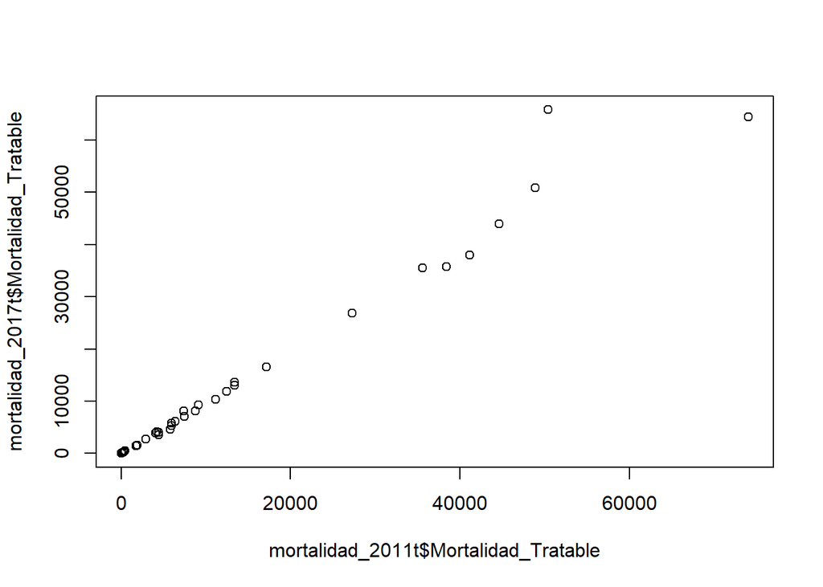

```r
#Se muestra la relación existente entre la Mortalidad Tratable en 2011 y 6 años después.
plot(mortalidad_2011t$Mortalidad_Tratable,mortalidad_2017t$Mortalidad_Tratable)
```

```r
#Se realiza el contraste.
wilcox.test(mortalidad_2011t$Mortalidad_Tratable,
            mortalidad_2017t$Mortalidad_Tratable, paired=TRUE, alternative="greater")
```

```
##
##  Wilcoxon signed rank test
##
## data:  mortalidad_2011t$Mortalidad_Tratable and mortalidad_2017t$Mortalidad_Tratable
## V = 468, p-value = 0.001409
## alternative hypothesis: true location shift is greater than 0
```